# M2 IngMath ML IFMA/IMPE

Ana Karina Fermin

20 janvier 2020

```r
library(tidyverse)
library(caret)
library(gridExtra)
library(grid)
```

We will use the twoClass dataset from *Applied Predictive Modeling*, the book of M. Kuhn and K. Johnson to illustrate the most classical supervised classification algorithms. We will use some *advanced* **R** packages: the **ggplot2** package for the figures and the **caret** package for the learning part. **caret** that provides an unified interface to many other packages.

# The twoClass dataset

We read first the dataset and use **ggplot2** to display it.

```r
library(AppliedPredictiveModeling)
library(RColorBrewer)
data(twoClassData)
twoClass <- cbind(as.data.frame(predictors),classes)
twoClassColor <- brewer.pal(3,'Set1')[1:2]
names(twoClassColor) <- c('Class1','Class2')

nrow(twoClass)
```

```
## [1] 208
```

```r
summary(twoClass)
```

```
##    PredictorA       PredictorB       classes
##  Min.   :0.0236   Min.   :0.0289   Class1:111
##  1st Qu.:0.1335   1st Qu.:0.1293   Class2: 97
##  Median :0.2490   Median :0.2248
##  Mean   :0.2502   Mean   :0.2360
##  3rd Qu.:0.3312   3rd Qu.:0.3016
##  Max.   :0.7060   Max.   :0.7342
```

```r
prop.table(table(twoClass$classes))
```

```
##
##    Class1    Class2
## 0.5336538 0.4663462
```

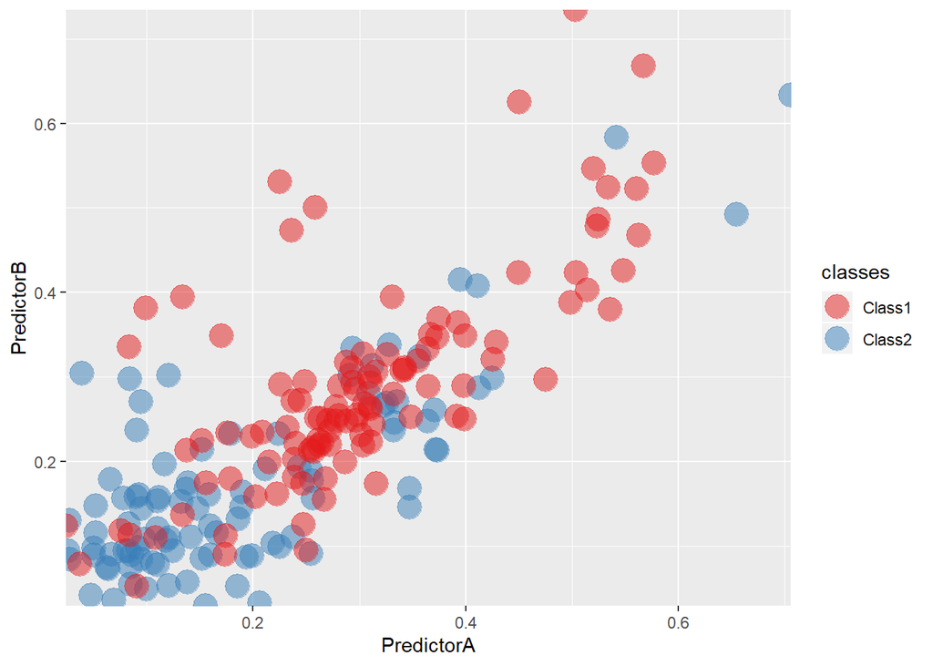

```r
ggplot(data = twoClass,aes(x = PredictorA, y = PredictorB)) +
  geom_point(aes(color = classes), size = 6, alpha = .5) +
  scale_colour_manual(name = 'classes', values = twoClassColor) +
  scale_x_continuous(expand = c(0,0)) +
  scale_y_continuous(expand = c(0,0))
```

We create a few functions that will be useful to display our classifiers.

```r
nbp <- 250;
PredA <- seq(min(twoClass$PredictorA), max(twoClass$PredictorA), length = nbp)
PredB <- seq(min(twoClass$PredictorB), max(twoClass$PredictorB), length = nbp)
Grid <- expand.grid(PredictorA = PredA, PredictorB = PredB)

PlotGrid <- function(pred,title) {
  surf <- (ggplot(data = twoClass, aes(x = PredictorA, y = PredictorB,
                                      color = classes)) +
          geom_tile(data = cbind(Grid, classes = pred), aes(fill = classes)) +
          scale_fill_manual(name = 'classes', values = twoClassColor) +
          ggtitle("Decision region") + theme(legend.text = element_text(size = 10)) +
  scale_colour_manual(name = 'classes', values = twoClassColor)) +
  scale_x_continuous(expand = c(0,0)) +
  scale_y_continuous(expand = c(0,0))
  pts <- (ggplot(data = twoClass, aes(x = PredictorA, y = PredictorB,
                                    color = classes)) +
          geom_contour(data = cbind(Grid, classes = pred), aes(z = as.numeric(classes)),
                       color = "red", breaks = c(1.5)) +
          geom_point(size = 4, alpha = .5) +
          ggtitle("Decision boundary") +
          theme(legend.text = element_text(size = 10)) +
          scale_colour_manual(name = 'classes', values = twoClassColor)) +
    scale_x_continuous(expand = c(0,0)) +
    scale_y_continuous(expand = c(0,0))
  grid.arrange(surf, pts, top = textGrob(title, gp = gpar(fontsize = 20)), ncol = 2)
}
```

```r
library("caret")
V <- 10
T <- 4
TrControl <- trainControl(method = "repeatedcv",
                          number = V,
                          repeats = T)

Seed <- 345
```

Finally, we provide a function that will store the accuracies for every resample and every model. We will also compute an accuracy based on the same data than the one used to learn in order to show the over-fitting phenomenon.

```r
ErrsCaret <- function(Model, Name) {
  Errs <- data.frame(t(postResample(predict(Model, newdata = twoClass), twoClass[["classes"]])),
                     Resample = "None", model = Name)
  rbind(Errs, data.frame(Model$resample, model = Name))
}

Errs <- data.frame()
```

We are now ready to define a function that take in input the current collection of accuracies, a name of a model, the corresponding formula and methods, as well as more parameters used to specify the model, and computes the trained model, displays its prediction in a figure and add the errors in the collection.

```r
CaretLearnAndDisplay <- function (Errs, Name, Formula, Method, ...) {
  set.seed(Seed)
  Model <- train(as.formula(Formula), data = twoClass, method = Method, trControl = TrControl, ...)
  Pred <- predict(Model, newdata = Grid)
  PlotGrid(Pred, Name)
  Errs <- rbind(Errs, ErrsCaret(Model, Name))
}
```

We can apply this function to any model available in **caret**. We will pick a few models and sort them depending on the heuristic used to define them. We will distinguish models coming from a statistical point of view in which one try to estimate the conditional law and plug it into the Bayes classifier and from an optimization point of view in which one try to enforce a *small* training error by minimizing a relaxed criterion.

## Statistical point of view

### Kernel Methods

In the nearest neighbor method, we need to supply a parameter: $k$ the number of neighbors used to define the kernel. We will compare visually the solution obtained with a few $k$ values.

```r
ErrsKNN <- data.frame()
KNNKS <- c(seq(1, 33, by = 4),seq(37,85, by = 8), seq(101, 200, by = 8))
for (k in KNNKS) {
  ErrsKNN <- CaretLearnAndDisplay(ErrsKNN, sprintf("k-NN with k=%i", k),
                           "classes ~ .","knn", tuneGrid = data.frame(k = c(k)))
}
```

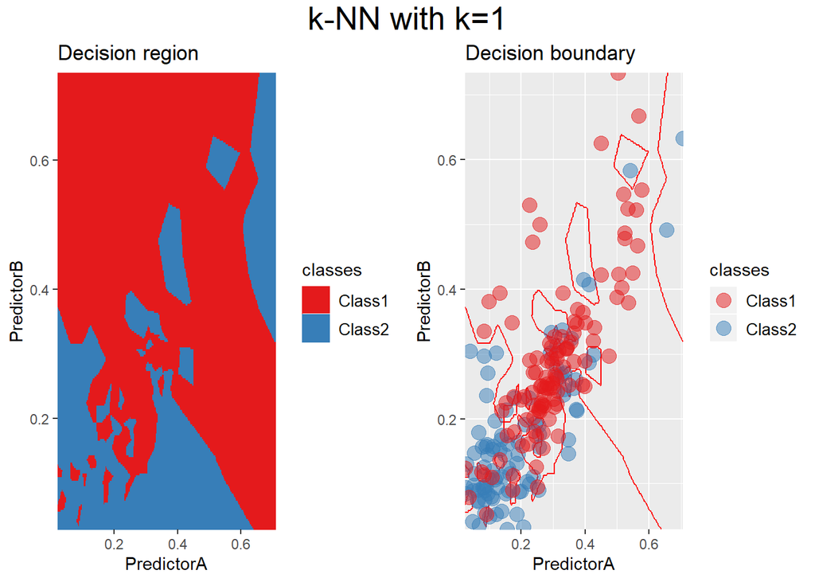

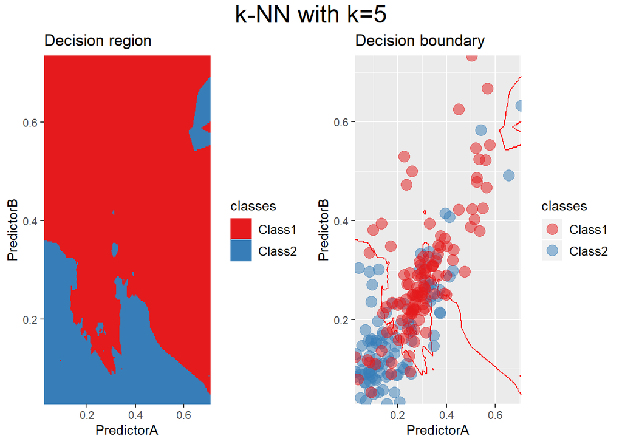

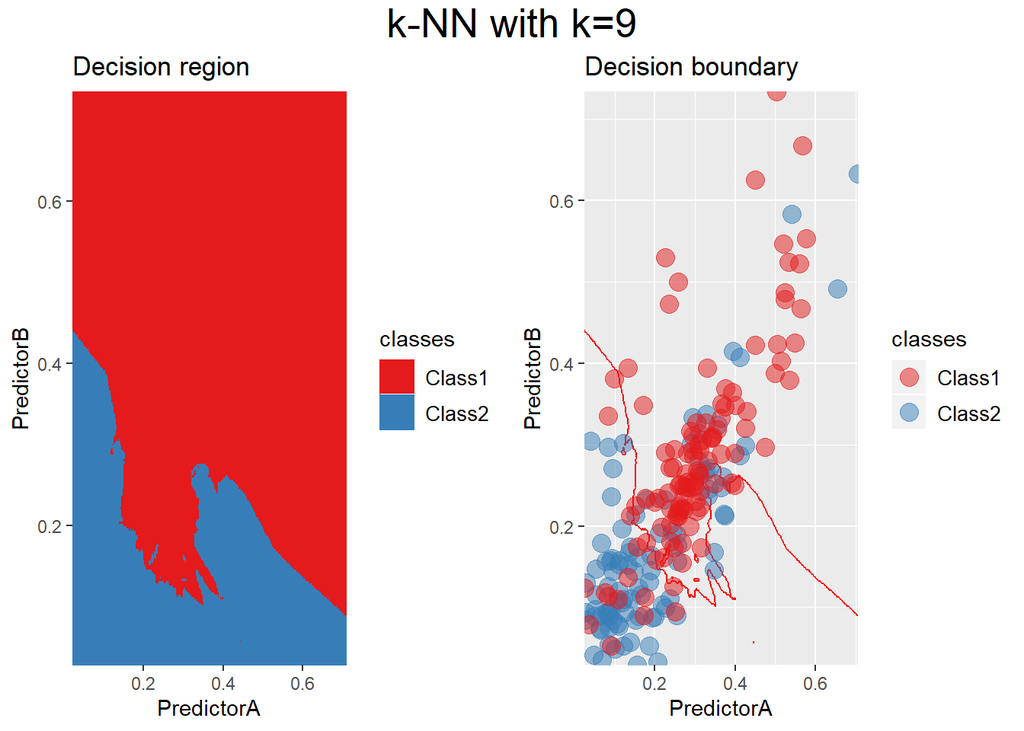

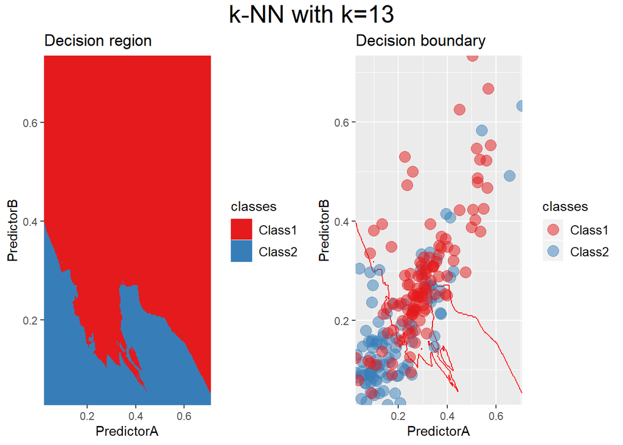

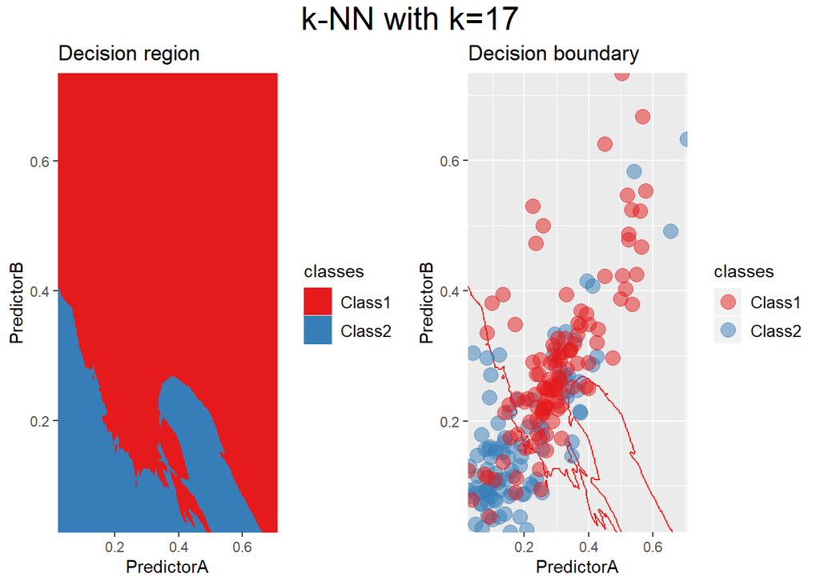

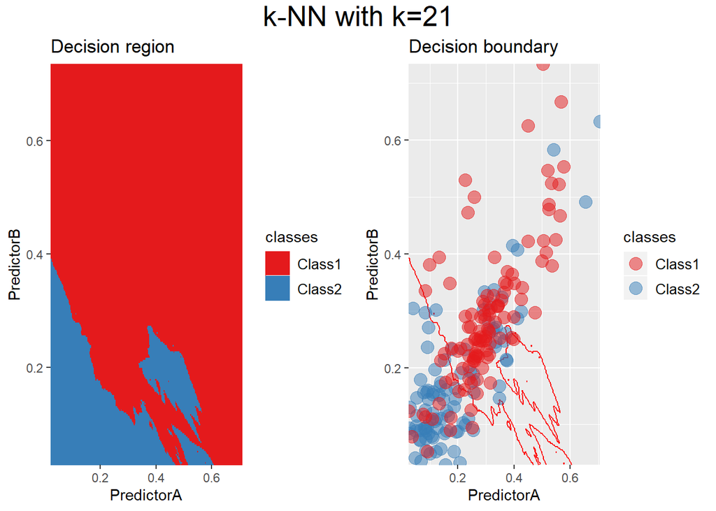

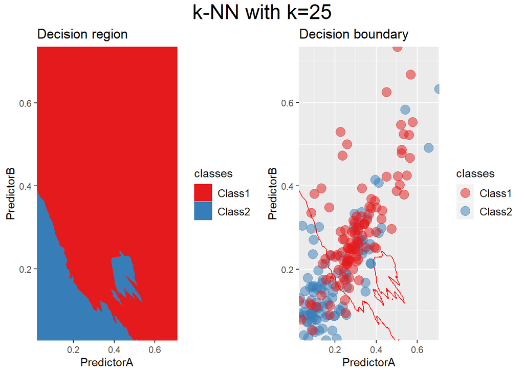

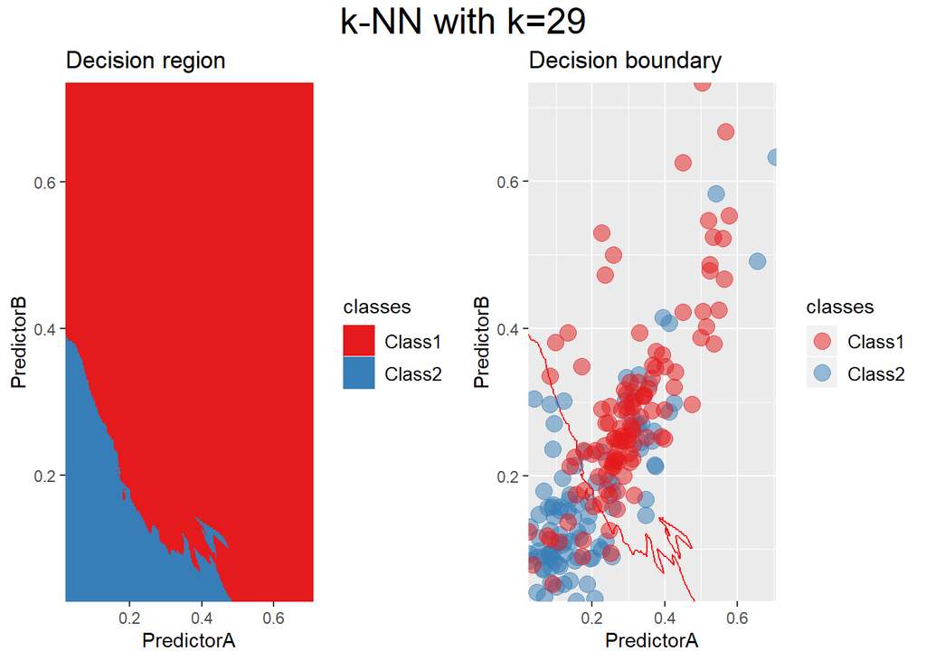

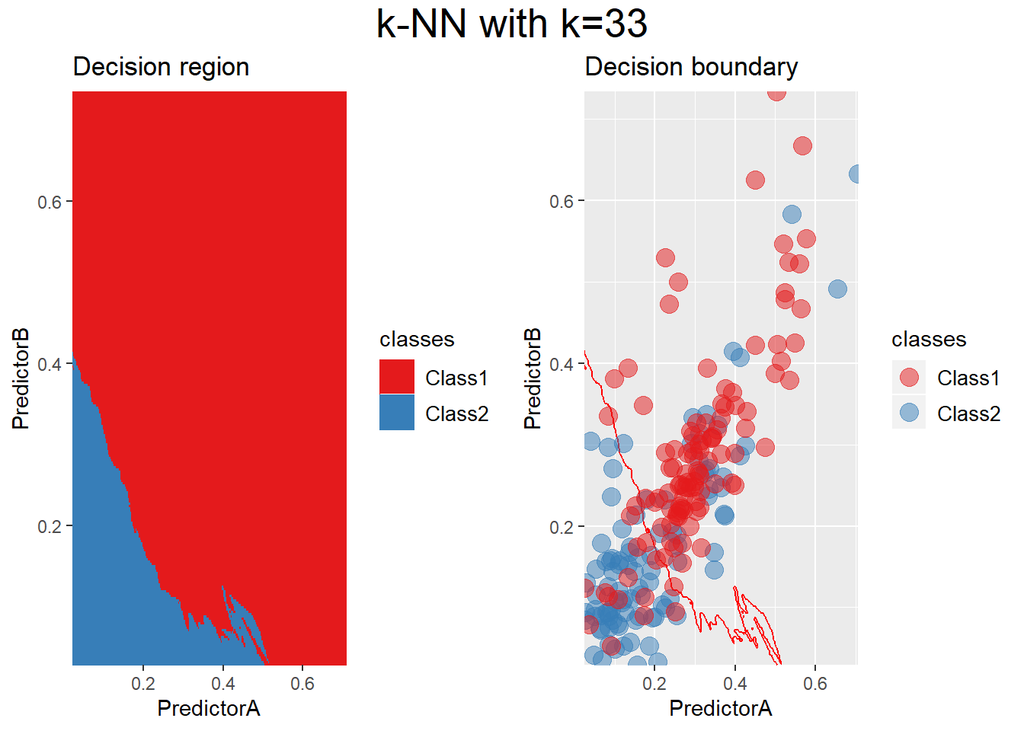

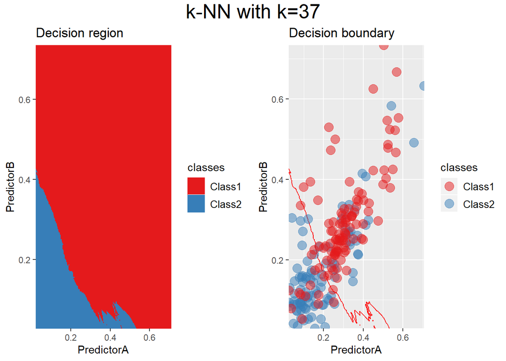

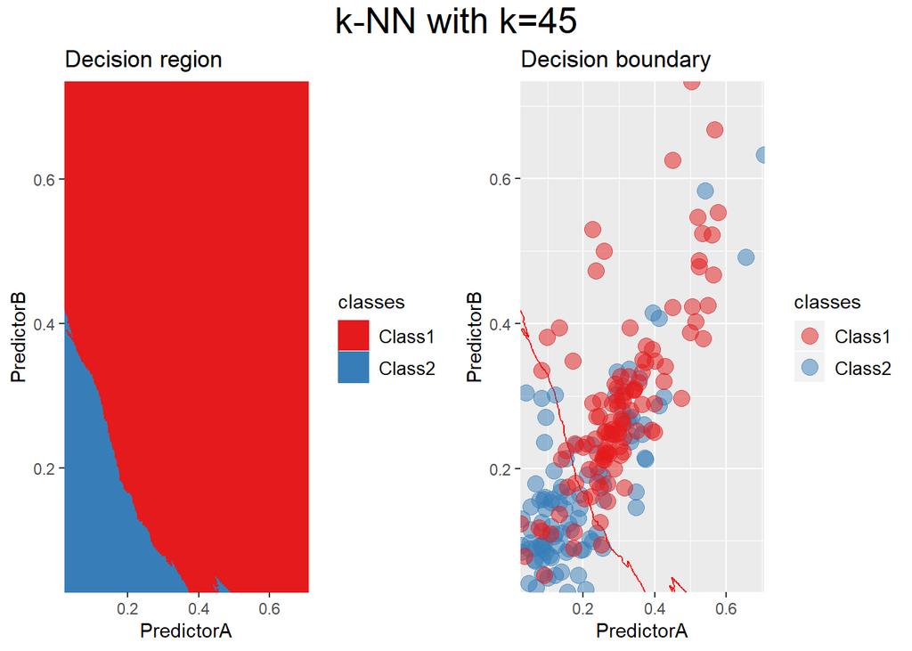

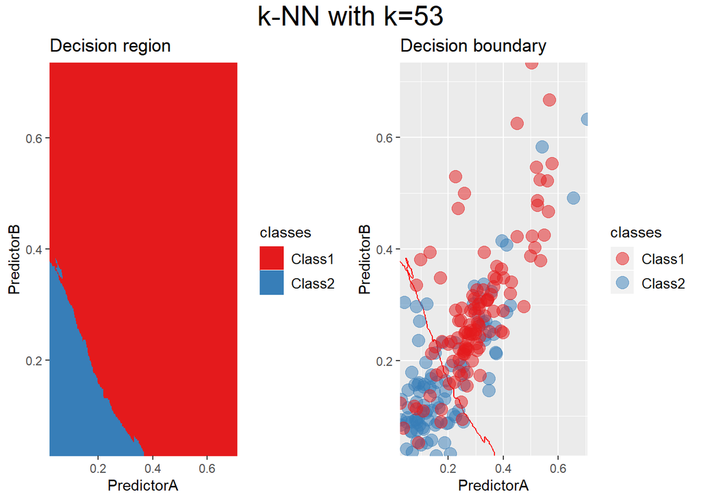

[17 more figures not shown]

```r
Errs <- rbind(Errs, ErrsKNN)
```

# Model comparison

We will now compare our model according to 4 criterion: - **Accuracy**: the *naive* empirical accuracy computed on the same dataset than the one used to learn the classifier, - **AccuracyCV**: the mean of the accuracies obtained by the resampling scheme, - **AccuracyInf**: a lowest bound on the mean accuracy obtained by substracting to the mean two times the standard deviation divided by the square root of the number of resamples. - **AccuracyPAC**: a highly probably bound on the accuracy obtained by substracting the standard deviation.

## Global comparison

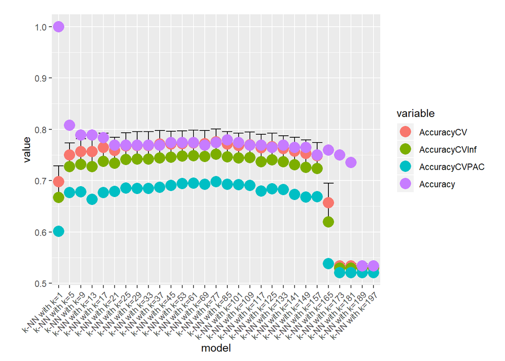

```r
ErrCaretAccuracy <- function(Errs) {
  Errs <- group_by(Errs, model)
  cbind(dplyr::summarize(Errs, mAccuracy = mean(Accuracy, na.rm = TRUE), mKappa = mean(Kappa, na.rm = TRUE),
                             sdAccuracy = sd(Accuracy, na.rm = TRUE), sdKappa = sd(Kappa, na.rm = TRUE)))
}

ErrAndPlotErrs <- function(Errs, simple = FALSE) {
  ErrCV <- ErrCaretAccuracy(dplyr::filter(Errs, !(Resample == "None")))
  ErrCVtmp <- transmute(ErrCV, AccuracyCV = mAccuracy, AccuracyCVInf = mAccuracy - 2 * sdAccuracy/sqrt(T * V),
                     AccuracyCVPAC = mAccuracy - sdAccuracy,
                     model = model)
  ErrEmp <- dplyr::select(dplyr::filter(Errs, (Resample == "None")), Accuracy, model)
  Err <- dplyr::left_join(ErrCVtmp, ErrEmp)
  if (simple) {
  print(ggplot(data = reshape2::melt(dplyr::select(Err, model, Accuracy, AccuracyCV),
                                     "model"),
               aes(x = model, y = value, color = variable)) +
          geom_point(size = 5) +
          theme(axis.text.x = element_text(angle = 45, hjust = 1),
                plot.margin = grid::unit(c(1, 1, .5, 1.5), "lines")))
  } else {
    print(ggplot(data = reshape2::melt(Err, "model"),
               aes(x = model, y = value, color = variable)) +
          geom_errorbar(data = ErrCV,
                        aes(x = model,
                            ymin = mAccuracy - 2 * sdAccuracy/sqrt(T * V),
                        ymax = mAccuracy + 2 * sdAccuracy/sqrt(T * V), y = mAccuracy), color = "black") +
          geom_point(size = 5) +
          theme(axis.text.x = element_text(angle = 45, hjust = 1),
                plot.margin = grid::unit(c(1, 1, .5, 1.5), "lines")))
  }
  Err
  }

Err <- ErrAndPlotErrs(Errs)
```

```r
FindBestErr <- function(Err) {
  for (name in names(Err)[!(names(Err) == "model")]) {
    ind <- which.max(Err[, name])
    writeLines(strwrap(paste("Best method according to", name, ":", Err[ind, "model"])))
    }
  }

FindBestErr(Err)
```

```
## Best method according to AccuracyCV : k-NN with k=77
## Best method according to AccuracyCVInf : k-NN with k=77
## Best method according to AccuracyCVPAC : k-NN with k=77
## Best method according to Accuracy : k-NN with k=1
```

### K-NN Comparison

We focus here on the choice of the neighborhood in the $k$ Nearest Neighbor method.

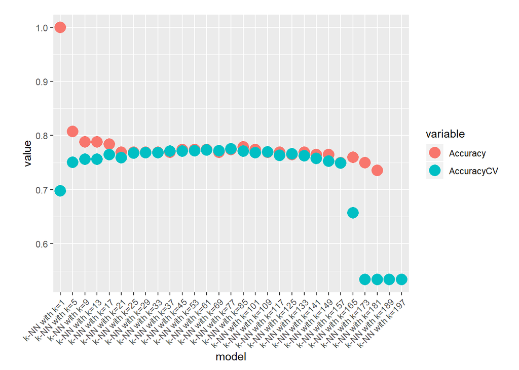

```r
ErrKNN <- ErrAndPlotErrs(ErrsKNN, simple = TRUE)
```

```r
FindBestErr(ErrKNN)
```

```
## Best method according to AccuracyCV : k-NN with k=77
## Best method according to AccuracyCVInf : k-NN with k=77
## Best method according to AccuracyCVPAC : k-NN with k=77
## Best method according to Accuracy : k-NN with k=1
```

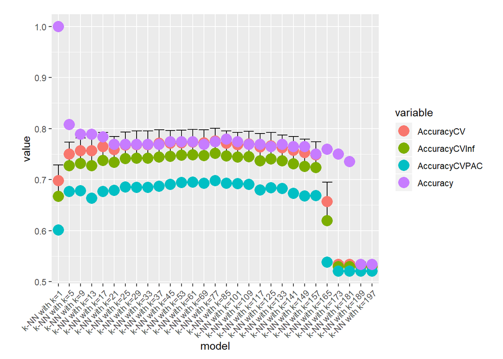

```r
ErrKNN <- ErrAndPlotErrs(ErrsKNN)
```

```r
FindBestErr(ErrKNN)
```

```
## Best method according to AccuracyCV : k-NN with k=77
## Best method according to AccuracyCVInf : k-NN with k=77
## Best method according to AccuracyCVPAC : k-NN with k=77
## Best method according to Accuracy : k-NN with k=1
```